# Assignment 1

YU Hong

2018/11/5

**Apply multiple linear regression to the Auto data set**

## 1. Produce a scatterplot matrix which includes all of the variables in the data set.

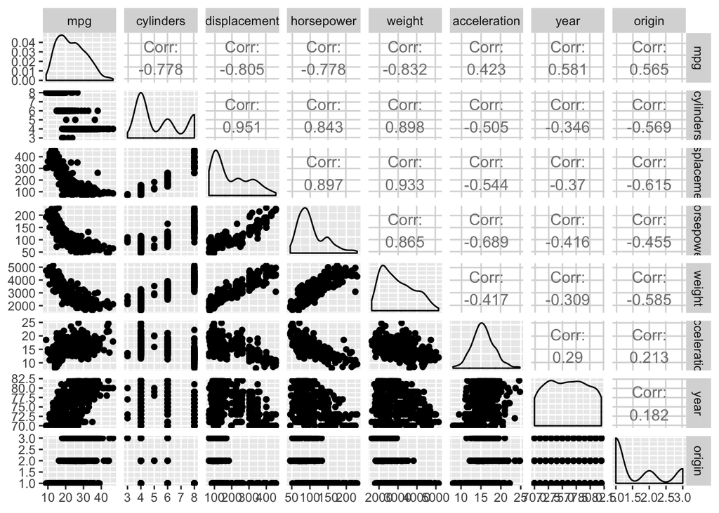

```r
library(ISLR)
Auto$name <- NULL

require(ggplot2)
require(GGally)
GGally::ggpairs(Auto)
```

## 2. Compute the matrix of correlations between all the relevant variables using the function cor().

```r
cor(Auto)
```

```
##                     mpg  cylinders displacement horsepower     weight
## mpg           1.0000000 -0.7776175   -0.8051269 -0.7784268 -0.8322442
## cylinders    -0.7776175  1.0000000    0.9508233  0.8429834  0.8975273
## displacement -0.8051269  0.9508233    1.0000000  0.8972570  0.9329944
## horsepower   -0.7784268  0.8429834    0.8972570  1.0000000  0.8645377
## weight       -0.8322442  0.8975273    0.9329944  0.8645377  1.0000000
## acceleration  0.4233285 -0.5046834   -0.5438005 -0.6891955 -0.4168392
## year          0.5805410 -0.3456474   -0.3698552 -0.4163615 -0.3091199
## origin        0.5652088 -0.5689316   -0.6145351 -0.4551715 -0.5850054
##              acceleration       year     origin
## mpg             0.4233285  0.5805410  0.5652088
## cylinders      -0.5046834 -0.3456474 -0.5689316
## displacement   -0.5438005 -0.3698552 -0.6145351
## horsepower     -0.6891955 -0.4163615 -0.4551715
## weight         -0.4168392 -0.3091199 -0.5850054
## acceleration    1.0000000  0.2903161  0.2127458
## year            0.2903161  1.0000000  0.1815277
## origin          0.2127458  0.1815277  1.0000000
```

## 3. With mpg as the response variable and other applicable variables as predictors test multiplelinear regression model.

Rank the predictors according to their relation with response and justify your answer.

Split the training set into three subsets.

```r
trainI <- sample(nrow(Auto), 0.7*nrow(Auto))
trainSet <- Auto[trainI,]
testSet <- Auto[-trainI,]

set.seed(1)
train1=sample(nrow(trainSet), nrow(trainSet) * 0.33)
train2and3 <- trainSet[-train1,]

train2=sample(nrow(train2and3), nrow(train2and3) * 0.5)
train3_<- train2and3[-train2,]

train3 <- sample(nrow(train3_), nrow(train3_))
listSet <-list(train1,train2,train3)
```

Find the best model according to K-flod cross-validation

```r
listModel <- list()
errorMin <- 10000
indexMin <- 0
for (i in 1:3) {
  validate <- trainSet[listSet[[i]],]
  subTrain <- trainSet[-listSet[[i]],]
  lm.fit <- lm(mpg~.,data = subTrain)
  listModel[[i]] <- (lm.fit)
  cv.error <- mean((validate$mpg-predict(lm.fit,validate)))
  if ((cv.error^2) < errorMin) {
    errorMin <- cv.error
    indexMin <- i
  }
}
summary(listModel[[indexMin]])
```

```
##
## Call:
## lm(formula = mpg ~ ., data = subTrain)
##
## Residuals:
##     Min      1Q  Median      3Q     Max
## -9.0890 -1.9387  0.0704  1.7831 10.9533
##
## Coefficients:
##                Estimate Std. Error t value Pr(>|t|)
## (Intercept)  -1.544e+01  6.713e+00  -2.301 0.022606 *
## cylinders    -3.615e-01  4.638e-01  -0.779 0.436780
## displacement  3.207e-02  1.014e-02   3.164 0.001837 **
## horsepower   -2.877e-03  1.739e-02  -0.165 0.868796
## weight       -8.273e-03  9.669e-04  -8.556 5.89e-15 ***
## acceleration  2.604e-01  1.370e-01   1.901 0.058901 .
## year          7.009e-01  7.404e-02   9.466  < 2e-16 ***
## origin        1.507e+00  3.965e-01   3.801 0.000199 ***
## ---
## Signif. codes:  0 '***' 0.001 '**' 0.01 '*' 0.05 '.' 0.1 ' ' 1
##
## Residual standard error: 3.196 on 174 degrees of freedom
## Multiple R-squared:  0.8477, Adjusted R-squared:  0.8415
## F-statistic: 138.3 on 7 and 174 DF,  p-value: < 2.2e-16
```

Order all variables depands on their p-values.

```r
sort(summary(listModel[[indexMin]])$coefficients[,4])#Pr(>|t|)
```

```
##         year       weight       origin displacement  (Intercept)
## 2.064410e-17 5.893082e-15 1.987586e-04 1.836818e-03 2.260575e-02
## acceleration    cylinders   horsepower
## 5.890112e-02 4.367804e-01 8.687958e-01
```

## 4. Use the * and : symbols to fit linear regression models with interaction effects.

All possible interactions and their p-values.

```r
lm.fit <- lm(mpg~year*weight*origin*cylinders*displacement*acceleration*horsepower,data = trainSet)
summary(lm.fit)
```

```
##
## Call:
## lm(formula = mpg ~ year * weight * origin * cylinders * displacement *
##     acceleration * horsepower, data = trainSet)
##
## Residuals:
##     Min      1Q  Median      3Q     Max
## -5.6374 -0.9754  0.0000  0.8887  7.3976
##
## Coefficients: (21 not defined because of singularities)
##                                                                     Estimate
## (Intercept)                                                       -3.069e+04
## year                                                               4.785e+02
## weight                                                             4.261e+01
## origin                                                             1.687e+04
## cylinders                                                          6.733e+03
## displacement                                                      -2.033e+02
## acceleration                                                      -3.858e+03
## horsepower                                                         9.917e+01
## year:weight                                                       -5.983e-01
## year:origin                                                       -3.413e+02
## weight:origin                                                     -3.661e+01
## year:cylinders                                                    -1.174e+02
## weight:cylinders                                                  -1.088e+01
## origin:cylinders                                                  -5.402e+03
## year:displacement                                                  2.935e+00
## weight:displacement                                               -1.509e-02
## origin:displacement                                                3.548e+02
## cylinders:displacement                                             7.139e+01
## year:acceleration                                                  4.492e+01
## weight:acceleration                                                1.458e-01
## origin:acceleration                                                4.688e+03
## cylinders:acceleration                                             1.040e+03
## displacement:acceleration                                         -1.097e+01
## year:horsepower                                                   -9.527e-02
## weight:horsepower                                                 -1.628e-02
## origin:horsepower                                                  4.283e+01
## cylinders:horsepower                                              -1.789e+01
## displacement:horsepower                                           -1.734e+00
## acceleration:horsepower                                           -4.131e+00
```

[output cut: 475 more lines]

```
## year:cylinders:displacement:acceleration:horsepower                  0.501
## weight:cylinders:displacement:acceleration:horsepower                0.491
## origin:cylinders:displacement:acceleration:horsepower                   NA
## year:weight:origin:cylinders:displacement:acceleration                  NA
## year:weight:origin:cylinders:displacement:horsepower                    NA
## year:weight:origin:cylinders:acceleration:horsepower                    NA
## year:weight:origin:displacement:acceleration:horsepower              0.708
## year:weight:cylinders:displacement:acceleration:horsepower           0.537
## year:origin:cylinders:displacement:acceleration:horsepower              NA
## weight:origin:cylinders:displacement:acceleration:horsepower            NA
## year:weight:origin:cylinders:displacement:acceleration:horsepower       NA
##
## Residual standard error: 2.26 on 167 degrees of freedom
## Multiple R-squared:  0.9493, Adjusted R-squared:  0.917
## F-statistic: 29.47 on 106 and 167 DF,  p-value: < 2.2e-16
```

```r
head(sort(summary(lm.fit)$coefficients[,4], decreasing=FALSE), n=10L)
```

```
##           year:origin:acceleration year:origin:cylinders:acceleration
##                          0.1207709                          0.1417924
##                origin:acceleration      origin:cylinders:acceleration
##                          0.1458104                          0.1679985
##        year:cylinders:acceleration             cylinders:acceleration
##                          0.1866276                          0.2120743
##                   weight:cylinders              year:weight:cylinders
##                          0.2742797                          0.2883064
##            weight:origin:cylinders       year:weight:origin:cylinders
##                          0.2945626                          0.2993264
```

```r
lm.fit <-lm(mpg~.
   +weight:origin:cylinders
   +year:weight:origin:cylinders
   +year:origin:cylinders:acceleration
   +year:origin:cylinders:displacement
   +origin:cylinders:displacement
   +origin:cylinders:acceleration
   +year:weight:cylinders
   +weight:cylinders
   +year:weight:origin
   +weight:origin
   ,data = trainSet)
summary(lm.fit)
```

```
##
## Call:
## lm(formula = mpg ~ . + weight:origin:cylinders + year:weight:origin:cylinders +
##     year:origin:cylinders:acceleration + year:origin:cylinders:displacement +
##     origin:cylinders:displacement + origin:cylinders:acceleration +
##     year:weight:cylinders + weight:cylinders + year:weight:origin +
##     weight:origin, data = trainSet)
##
## Residuals:
##     Min      1Q  Median      3Q     Max
## -8.4562 -1.4518 -0.0353  1.3037 10.8461
##
## Coefficients:
##                                      Estimate Std. Error t value Pr(>|t|)
## (Intercept)                         4.097e+01  3.055e+01   1.341 0.181185
## cylinders                          -5.954e+00  1.011e+00  -5.888 1.22e-08
## displacement                       -5.084e-02  3.279e-02  -1.550 0.122272
## horsepower                         -4.255e-02  1.368e-02  -3.111 0.002078
## weight                             -9.777e-03  4.017e-03  -2.434 0.015627
## acceleration                       -7.344e-01  2.595e-01  -2.830 0.005017
## year                                5.965e-01  3.855e-01   1.548 0.122967
## origin                             -8.172e+00  2.901e+00  -2.817 0.005220
## cylinders:weight                    4.351e-04  2.607e-03   0.167 0.867563
## weight:origin                      -5.666e-03  1.445e-02  -0.392 0.695362
## cylinders:weight:origin             6.987e-03  4.272e-03   1.636 0.103142
## cylinders:displacement:origin      -3.011e-02  1.658e-02  -1.817 0.070462
## cylinders:acceleration:origin      -5.299e-01  1.744e-01  -3.039 0.002619
## cylinders:weight:year               6.718e-06  3.235e-05   0.208 0.835661
## weight:year:origin                  7.684e-05  1.789e-04   0.429 0.667925
## cylinders:weight:year:origin       -9.747e-05  5.322e-05  -1.831 0.068226
## cylinders:acceleration:year:origin  8.470e-03  2.164e-03   3.914 0.000116
## cylinders:displacement:year:origin  5.356e-04  2.213e-04   2.420 0.016203
##
## (Intercept)
## cylinders                          ***
## displacement
## horsepower                         **
## weight                             *
## acceleration                       **
## year
## origin                             **
## cylinders:weight
## weight:origin
## cylinders:weight:origin
## cylinders:displacement:origin      .
## cylinders:acceleration:origin      **
## cylinders:weight:year
## weight:year:origin
## cylinders:weight:year:origin       .
## cylinders:acceleration:year:origin ***
## cylinders:displacement:year:origin *
## ---
## Signif. codes:  0 '***' 0.001 '**' 0.01 '*' 0.05 '.' 0.1 ' ' 1
##
## Residual standard error: 2.667 on 256 degrees of freedom
## Multiple R-squared:  0.8916, Adjusted R-squared:  0.8844
## F-statistic: 123.9 on 17 and 256 DF,  p-value: < 2.2e-16
```

```r
mean((testSet$mpg-predict(lm.fit,testSet)))
```

```
## [1] -0.2458356
```

## 5. Which of the different transformations of the variables make sense

such as log(X), sqrt and polynomial expansion

As we already know that “year” is the most significant variable to mpg, so I choose “year” as the exampled variable in this question.

### Liner

```r
lm.liner <- lm(mpg~year,data = trainSet)
mean(testSet$mpg-predict(lm.liner,testSet))
```

```
## [1] 0.1593329
```

### Log

```r
lm.log <- lm(mpg~log(year),data = trainSet)
mean(testSet$mpg-predict(lm.log,testSet))
```

```
## [1] 0.1542746
```

```r
lm.sqrt <- lm(mpg~I(year^2),data = trainSet)
mean(testSet$mpg-predict(lm.sqrt,testSet))
```

```
## [1] 0.1631434
```

### Polynomial expansion

```r
lm.p2 <- lm(mpg~poly(year,2),data = trainSet)
mean(testSet$mpg-predict(lm.p2,testSet))
```

```
## [1] 0.166311
```

```r
lm.p3 <- lm(mpg~poly(year,3),data = trainSet)
mean(testSet$mpg-predict(lm.p3,testSet))
```

```
## [1] 0.2210128
```

```r
lm.p4 <- lm(mpg~poly(year,4),data = trainSet)
mean(testSet$mpg-predict(lm.p4,testSet))
```

```
## [1] 0.1381466
```

#### anova

```r
anova(lm.liner, lm.log, lm.sqrt, lm.p2, lm.p3, lm.p4)
```

```
## Analysis of Variance Table
##
## Model 1: mpg ~ year
## Model 2: mpg ~ log(year)
## Model 3: mpg ~ I(year^2)
## Model 4: mpg ~ poly(year, 2)
## Model 5: mpg ~ poly(year, 3)
## Model 6: mpg ~ poly(year, 4)
##   Res.Df   RSS Df Sum of Sq      F  Pr(>F)
## 1    272 10738
## 2    272 10804  0   -65.601
## 3    272 10679  0   124.829
## 4    271 10424  1   255.278 6.6536 0.01043 *
## 5    270 10398  1    26.271 0.6847 0.40869
## 6    269 10321  1    76.747 2.0003 0.15842
## ---
## Signif. codes:  0 '***' 0.001 '**' 0.01 '*' 0.05 '.' 0.1 ' ' 1
```

In this result we can find that **2degree polynominal** expension make ‘year’ more significant in the model.